# Computer Lab 1

Dhyey Patel, Erik Anders

4/18/2020

##1. Bernoulli … again. Let y 1 , …, y n |θ ∼ Bern(θ), and assume that you have obtained a sample with s = 5 successes in n = 20 trials. Assume a Beta(α 0 , β 0 ) prior for θ and let α 0 = β 0 = 2.

1. Draw random numbers from the posterior θ|y ∼ Beta(α 0 + s, β 0 + f ), y = (y 1 , . . . , y n ), and verify graphically that the posterior mean and standard de- viation converges to the true values as the number of random draws grows large.

```
## [1] "True mean"
```

```
## [1] 0.2916667
```

```
## [1] "True sd"
```

```
## [1] 0.008263889
```

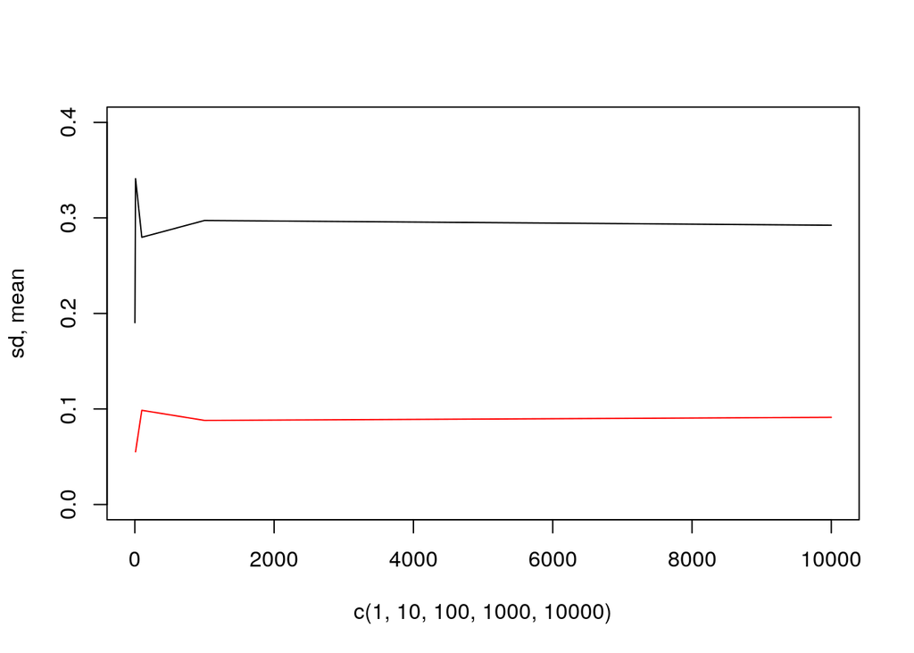

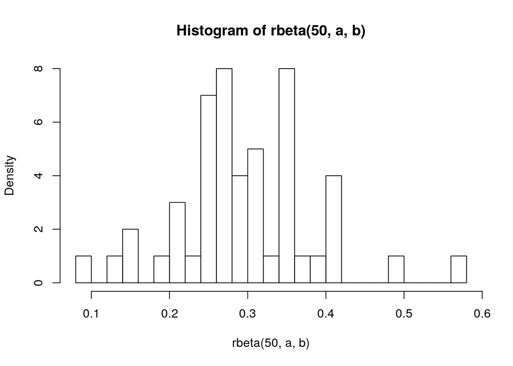

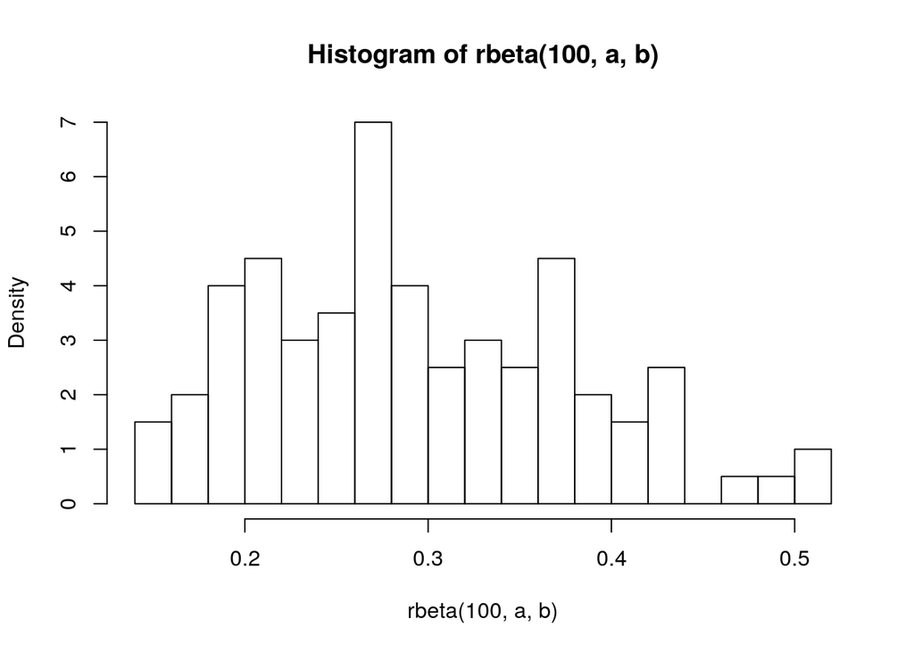

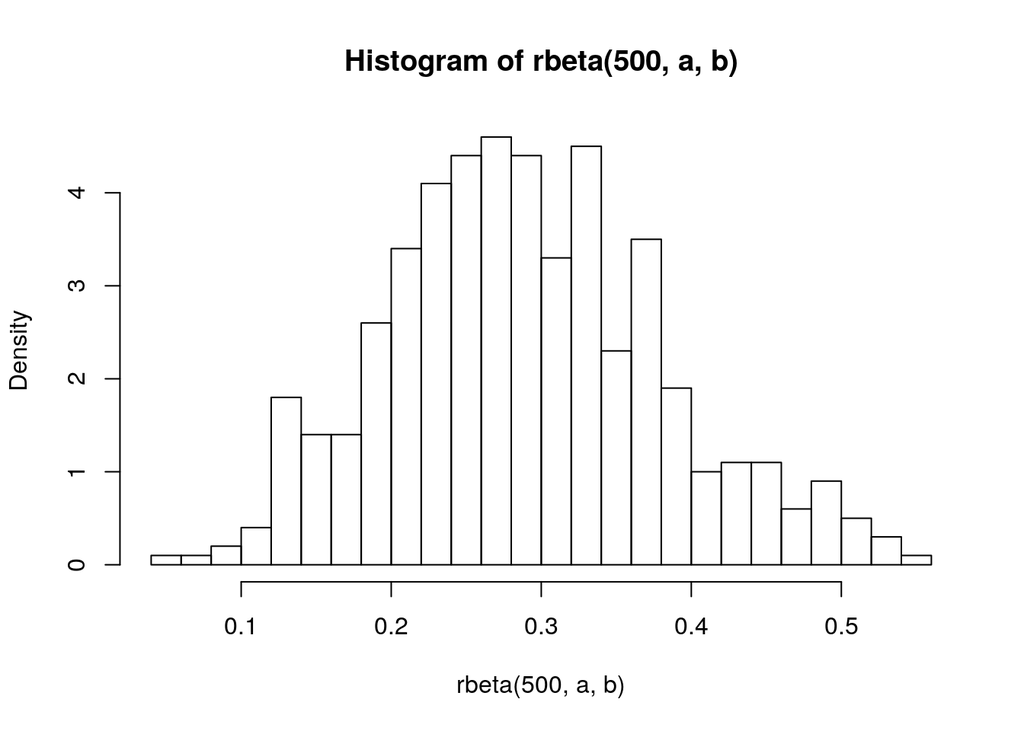

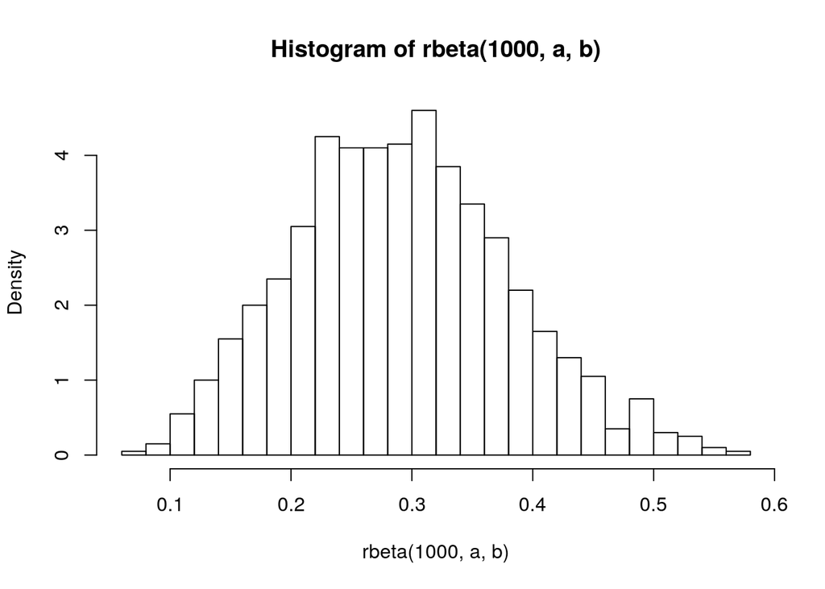

As we can see from the plots, as n increases from 50 to 1000, the mean visually converges to the true mean 0.29.